# **Analysis of Titanic shipwreck**

Mohamed Faadil

## **Data Set Description**

This Data set has 891 rows and 12 columns. There are 11 predictor variables and 1 target variable.

```
  PassengerId Survived Pclass
1           1        0      3
2           2        1      1
3           3        1      3
4           4        1      1
5           5        0      3
6           6        0      3
                                                 Name    Sex Age SibSp Parch
1                             Braund, Mr. Owen Harris   male  22     1     0
2 Cumings, Mrs. John Bradley (Florence Briggs Thayer) female  38     1     0
3                              Heikkinen, Miss. Laina female  26     0     0
4        Futrelle, Mrs. Jacques Heath (Lily May Peel) female  35     1     0
5                            Allen, Mr. William Henry   male  35     0     0
6                                    Moran, Mr. James   male  NA     0     0
            Ticket   Fare Cabin Embarked
1        A/5 21171  7.250              S
2         PC 17599 71.283   C85        C
3 STON/O2. 3101282  7.925              S
4           113803 53.100  C123        S
5           373450  8.050              S
6           330877  8.458              Q
```

## **Correlation Plot**

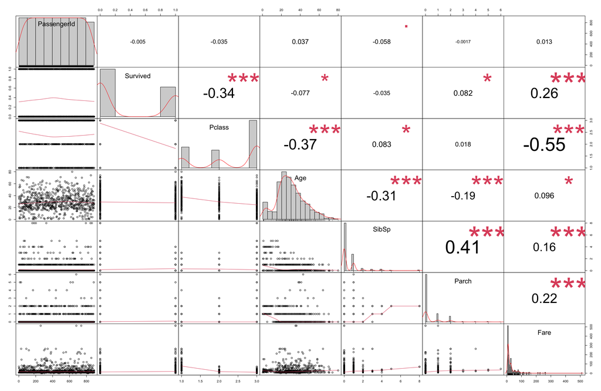

## **Explanatory Data Analysis**

```r
df_dummy <- fastDummies::dummy_cols(df_clean,
select_columns = c("Sex","Embarked"))
colnames(df_dummy)
```

```
 "Survived"   "Pclass"     "Sex"        "Age"        "SibSp"
 "Parch"      "Fare"       "Embarked"   "Sex_female" "Sex_male"
 "Embarked_"  "Embarked_C" "Embarked_Q" "Embarked_S"
```

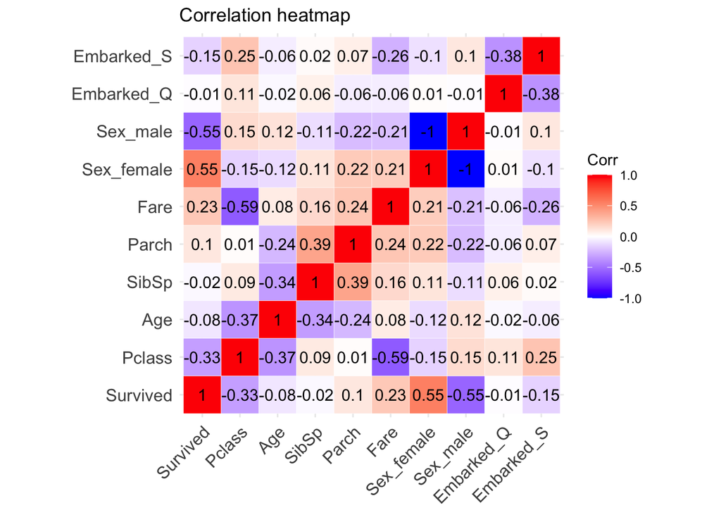

```r
df_dummy <- df_dummy[c(1,2,4,5,6,7,9,10,12,13,14)]
corr <- (cor(df_dummy[,-9]))
ggcorrplot(corr, hc.order = F, outline.col = "white",
           lab = TRUE, title= "Correlation heatmap")
```

```r
summary(df_clean)
```

```
    Survived         Pclass         Sex                 Age
 Min.   :0.000   Min.   :1.00   Length:500         Min.   : 0.75
 1st Qu.:0.000   1st Qu.:1.00   Class :character   1st Qu.:21.00
 Median :0.000   Median :2.00   Mode  :character   Median :28.00
 Mean   :0.414   Mean   :2.23                      Mean   :29.98
 3rd Qu.:1.000   3rd Qu.:3.00                      3rd Qu.:38.00
 Max.   :1.000   Max.   :3.00                      Max.   :80.00
     SibSp           Parch            Fare         Embarked
 Min.   :0.000   Min.   :0.000   Min.   :  0.0   Length:500
 1st Qu.:0.000   1st Qu.:0.000   1st Qu.:  8.1   Class :character
 Median :0.000   Median :0.000   Median : 16.1   Mode  :character
 Mean   :0.536   Mean   :0.434   Mean   : 34.0
 3rd Qu.:1.000   3rd Qu.:1.000   3rd Qu.: 32.8
 Max.   :5.000   Max.   :5.000   Max.   :512.3
```

```r
summary(subset(df_clean, df_clean$Survived ==0))
```

```
    Survived     Pclass         Sex                 Age         SibSp
 Min.   :0   Min.   :1.00   Length:293         Min.   : 1   Min.   :0.000
 1st Qu.:0   1st Qu.:2.00   Class :character   1st Qu.:21   1st Qu.:0.000
 Median :0   Median :3.00   Mode  :character   Median :28   Median :0.000
 Mean   :0   Mean   :2.46                      Mean   :31   Mean   :0.549
 3rd Qu.:0   3rd Qu.:3.00                      3rd Qu.:40   3rd Qu.:1.000
 Max.   :0   Max.   :3.00                      Max.   :71   Max.   :5.000
     Parch            Fare         Embarked
 Min.   :0.000   Min.   :  0.0   Length:293
 1st Qu.:0.000   1st Qu.:  7.9   Class :character
 Median :0.000   Median : 13.0   Mode  :character
 Mean   :0.362   Mean   : 24.7
 3rd Qu.:0.000   3rd Qu.: 27.0
 Max.   :5.000   Max.   :263.0
```

```r
summary(subset(df_clean, df_clean$Survived ==1))
```

```
    Survived     Pclass        Sex                 Age            SibSp
 Min.   :1   Min.   :1.0   Length:207         Min.   : 0.75   Min.   :0.000
 1st Qu.:1   1st Qu.:1.0   Class :character   1st Qu.:19.00   1st Qu.:0.000
 Median :1   Median :2.0   Mode  :character   Median :28.00   Median :0.000
 Mean   :1   Mean   :1.9                      Mean   :28.51   Mean   :0.517
 3rd Qu.:1   3rd Qu.:3.0                      3rd Qu.:36.00   3rd Qu.:1.000
 Max.   :1   Max.   :3.0                      Max.   :80.00   Max.   :4.000
     Parch            Fare         Embarked
 Min.   :0.000   Min.   :  0.0   Length:207
 1st Qu.:0.000   1st Qu.: 13.0   Class :character
 Median :0.000   Median : 26.2   Mode  :character
 Mean   :0.536   Mean   : 47.2
 3rd Qu.:1.000   3rd Qu.: 64.2
 Max.   :5.000   Max.   :512.3
```

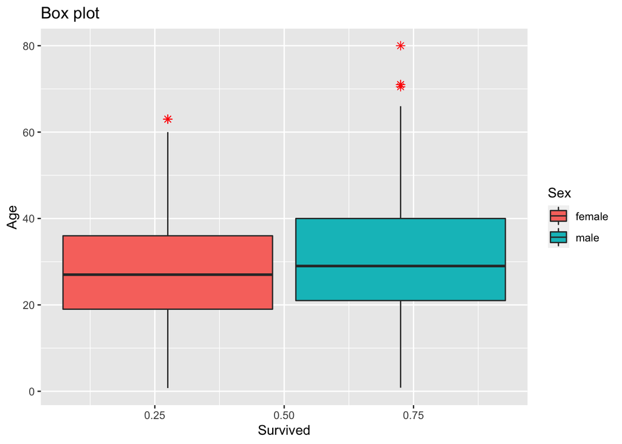

```r
#Bar Plots Survived vs Non-Survived
ggplot(df_clean, aes(x=Survived, y=Age, fill=Sex)) +
  geom_boxplot(outlier.colour="red", outlier.shape=8,
               outlier.size=2, notch=FALSE) +
  labs(title="Box plot",
       x = "Survived",
       y = "Age")
```

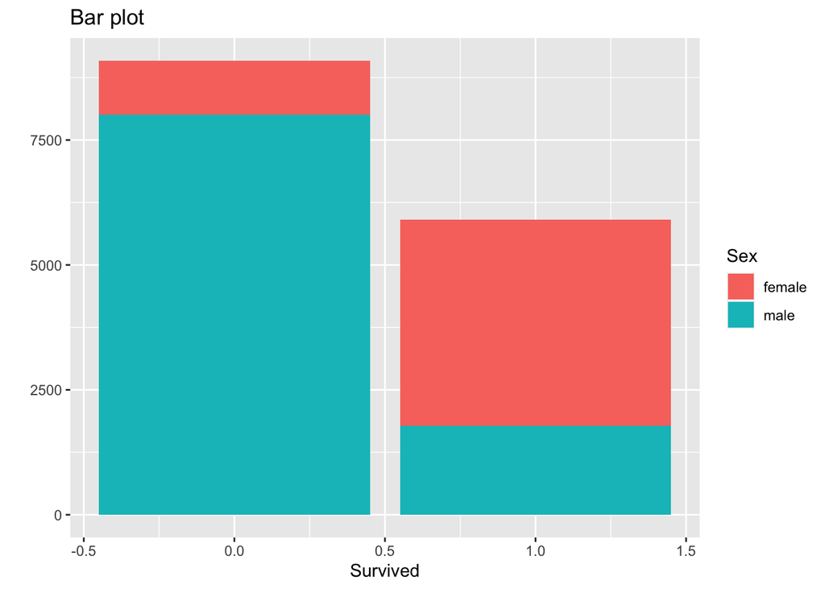

```r
ggplot(df_clean, aes(x=Survived, y=Age, fill=Sex)) +
  geom_bar(stat="identity") +
  labs(title="Bar plot",
       x = "Survived",
       y = "")
```

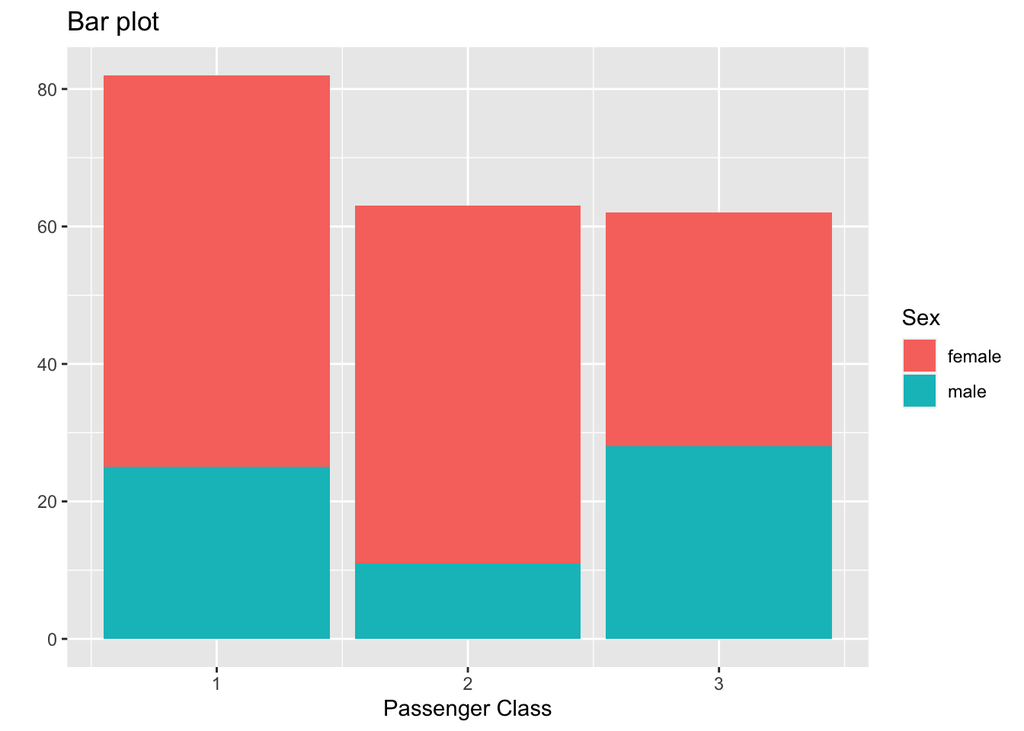

```r
ggplot(df_clean, aes(x=Pclass, y=Survived, fill=Sex)) +
  geom_bar(stat="identity") +
  labs(title="Bar plot",
       x = "Passenger Class",
       y = "")
```

## **Logistic Regression**

Building logistic regression classification models with below classes.

logistic regression of survived passengers as a function of passenger class. Passenger class is significant in determining the survival at 95% confidence interval

```r
## Passenger Class:
m <- glm(Survived~Pclass,
         data = df_dummy , family = binomial)
summary(m)
```

```
Call:
glm(formula = Survived ~ Pclass, family = binomial, data = df_dummy)

Deviance Residuals:
   Min      1Q  Median      3Q     Max
 -1.45   -0.79   -0.79    1.01    1.62

Coefficients:
            Estimate Std. Error z value Pr(>|z|)
(Intercept)    1.437      0.268    5.36  8.2e-08 ***
Pclass        -0.814      0.115   -7.06  1.7e-12 ***
---
Signif. codes:  0 '***' 0.001 '**' 0.01 '*' 0.05 '.' 0.1 ' ' 1

(Dispersion parameter for binomial family taken to be 1)

    Null deviance: 678.28  on 499  degrees of freedom
Residual deviance: 624.75  on 498  degrees of freedom
AIC: 628.7

Number of Fisher Scoring iterations: 4
```

##Adjusting for age:

Ran anova test on the following logistic regression model.

Categorical variable: passenger class

Covariate : Age

They are both significant in determining the survival of passenger

```r
library(car)
Anova(glm(Survived~Pclass + Age,
         data = df_dummy , family = binomial), type = 3, test.statistic = "F")
```

```
Analysis of Deviance Table (Type III tests)

Response: Survived
Error estimate based on Pearson residuals

          Sum Sq  Df F values     Pr(>F)
Pclass        78   1     76.3    < 2e-16 ***
Age           28   1     27.3 0.00000026 ***
Residuals    506 497
---
Signif. codes:  0 '***' 0.001 '**' 0.01 '*' 0.05 '.' 0.1 ' ' 1
```

## Regression with Gender

Looking below we can determine gender is significant in determining the survival of passenger

```r
m <- glm(Survived~Sex_female,
         data = df_dummy , family = binomial)
summary(m)
```

```
Call:
glm(formula = Survived ~ Sex_female, family = binomial, data = df_dummy)

Deviance Residuals:
   Min      1Q  Median      3Q     Max
-1.691  -0.678  -0.678   0.740   1.780

Coefficients:
            Estimate Std. Error z value Pr(>|z|)
(Intercept)   -1.355      0.140   -9.66   <2e-16 ***
Sex_female     2.511      0.221   11.36   <2e-16 ***
---
Signif. codes:  0 '***' 0.001 '**' 0.01 '*' 0.05 '.' 0.1 ' ' 1

(Dispersion parameter for binomial family taken to be 1)

    Null deviance: 678.28  on 499  degrees of freedom
Residual deviance: 523.57  on 498  degrees of freedom
AIC: 527.6

Number of Fisher Scoring iterations: 4
```

#Adjusting for age:

Ran anova test on the followinglogistic regression model.

Categorical variable: Sex

Covariate : Age

```r
Anova(glm(Survived~Sex_female+Age,
          data = df_dummy , family = binomial), type = 3, test.statistic = "F")
```

```
Analysis of Deviance Table (Type III tests)

Response: Survived
Error estimate based on Pearson residuals

           Sum Sq  Df F values Pr(>F)
Sex_female    151   1   150.55 <2e-16 ***
Age             0   1     0.26   0.61
Residuals     500 497
---
Signif. codes:  0 '***' 0.001 '**' 0.01 '*' 0.05 '.' 0.1 ' ' 1
```

## Family

Looking below we can determine Family is significant in determining the survival of passenger

```r
m <- glm(Survived~Parch,
         data = df_dummy , family = binomial)
summary(m)
```

```
Call:
glm(formula = Survived ~ Parch, family = binomial, data = df_dummy)

Deviance Residuals:
   Min      1Q  Median      3Q     Max
-1.520  -0.991  -0.991   1.376   1.376

Coefficients:
            Estimate Std. Error z value Pr(>|z|)
(Intercept)   -0.457      0.103   -4.42  0.00001 ***
Parch          0.247      0.109    2.26    0.024 *
---
Signif. codes:  0 '***' 0.001 '**' 0.01 '*' 0.05 '.' 0.1 ' ' 1

(Dispersion parameter for binomial family taken to be 1)

    Null deviance: 678.28  on 499  degrees of freedom
Residual deviance: 673.08  on 498  degrees of freedom
AIC: 677.1

Number of Fisher Scoring iterations: 4
```

#Adjusting for age:

Ran anova test on the following logistic regression model.

Categorical variable: family

Covariate : Age

Both are not significant at 95 % CI to determine survival

```r
Anova(glm(Survived~Parch+Age,
          data = df_dummy , family = binomial), type = 3, test.statistic = "F")
```

```
Analysis of Deviance Table (Type III tests)

Response: Survived
Error estimate based on Pearson residuals

          Sum Sq  Df F values Pr(>F)
Parch          4   1     3.48  0.063 .
Age            2   1     1.91  0.167
Residuals    500 497
---
Signif. codes:  0 '***' 0.001 '**' 0.01 '*' 0.05 '.' 0.1 ' ' 1
```

## Siblings

Looking below we can determine sibling is not significant

```r
m <- glm(Survived~SibSp,
         data = df_dummy , family = binomial)
summary(m)
```

```
Call:
glm(formula = Survived ~ SibSp, family = binomial, data = df_dummy)

Deviance Residuals:
   Min      1Q  Median      3Q     Max
 -1.04   -1.04   -1.03    1.32    1.38

Coefficients:
            Estimate Std. Error z value Pr(>|z|)
(Intercept)  -0.3278     0.1043   -3.14   0.0017 **
SibSp        -0.0368     0.0969   -0.38   0.7042
---
Signif. codes:  0 '***' 0.001 '**' 0.01 '*' 0.05 '.' 0.1 ' ' 1

(Dispersion parameter for binomial family taken to be 1)

    Null deviance: 678.28  on 499  degrees of freedom
Residual deviance: 678.14  on 498  degrees of freedom
AIC: 682.1

Number of Fisher Scoring iterations: 4
```

#Adjusting for age:

Ran anova test on the following logistic regression model.

Categorical variable: Sibling

Covariate : Age

```r
Anova(glm(Survived~SibSp+Age,
          data = df_dummy , family = binomial), type = 3, test.statistic = "F")
```

```
Analysis of Deviance Table (Type III tests)

Response: Survived
Error estimate based on Pearson residuals

          Sum Sq  Df F values Pr(>F)
SibSp          1   1     1.18  0.278
Age            5   1     4.64  0.032 *
Residuals    501 497
---
Signif. codes:  0 '***' 0.001 '**' 0.01 '*' 0.05 '.' 0.1 ' ' 1
```

## **Logistic Regression Classification Model**

Fare is not significant in determining survival at 95% CI.

```r
#building the final logistic regression classification model

set.seed(64)
split = sample.split(df_dummy$Survived, SplitRatio = 0.8)
training_set = subset(df_dummy, split == TRUE)
test_set = subset(df_dummy, split == FALSE)
training_set[-1] = scale(training_set[-1])
test_set[-1] = scale(test_set[-1])

classifier = glm(formula = Survived ~Pclass+Sex_female+Fare+Age,
                 family = binomial,
                 data = training_set)

summary(classifier)
```

```
Call:
glm(formula = Survived ~ Pclass + Sex_female + Fare + Age, family = binomial,
    data = training_set)

Deviance Residuals:
   Min      1Q  Median      3Q     Max
-2.477  -0.712  -0.417   0.615   2.368

Coefficients:
            Estimate Std. Error z value Pr(>|z|)
(Intercept)   -0.460      0.132   -3.48  0.00051 ***
Pclass        -1.075      0.179   -6.00    2e-09 ***
Sex_female     1.283      0.136    9.44  < 2e-16 ***
Fare          -0.265      0.149   -1.77  0.07601 .
Age           -0.420      0.144   -2.91  0.00360 **
---
Signif. codes:  0 '***' 0.001 '**' 0.01 '*' 0.05 '.' 0.1 ' ' 1

(Dispersion parameter for binomial family taken to be 1)

    Null deviance: 542.90  on 399  degrees of freedom
Residual deviance: 365.23  on 395  degrees of freedom
AIC: 375.2

Number of Fisher Scoring iterations: 4
```

## **Predicting Test Set Results**

We have used threshold as 0.5 to perform classification.

```r
# Predicting the Test set results
model.probs <- predict(classifier, test_set, type = "response")
model.pred <- rep(0, length(model.probs))
model.pred[model.probs > 0.5] <- 1
```

## **Confusion Matrix**

```r
# Making the Confusion Matrix
table(model.pred, test_set$Survived)
```

```
model.pred  0  1
         0 48 10
         1 11 31
```

```r
# Accuracy
1- mean(model.pred != test_set$Survived)
```

```
 0.79
```

```r
# ROC curve
#install.packages("pROC")
library(pROC)
g <- roc(test_set$Survived ~ model.probs)
print(g)
```

```
Call:
roc.formula(formula = test_set$Survived ~ model.probs)

Data: model.probs in 59 controls (test_set$Survived 0) < 41 cases (test_set$Survived 1).
Area under the curve: 0.815
```

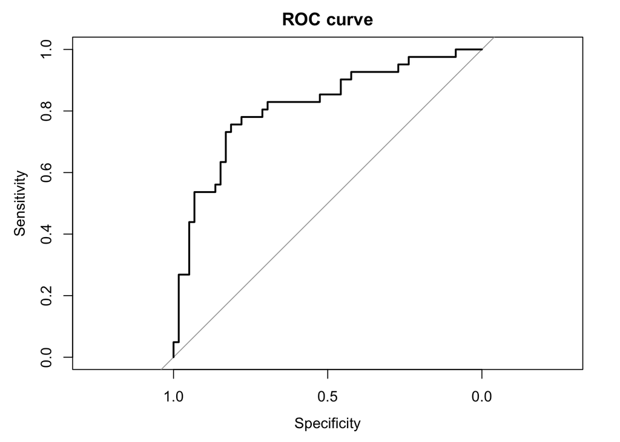

```r
plot(g, main = "ROC curve")
```